# Practical Lab 3 - Vanilla CNN and Fine-Tune VGG16 - for Dogs and Cats Classification

- Student Name : Akshata Madhav.
- Student ID : 8944328
- Section 2

## Step 1: Obtain the Data: Get the Dogs vs Cats dataset (see class' notebook, only 5000, not 25,000, images are required, these image set is defined in the notebook)

## <sub>Source for the dataset:</sub>

(https://www.kaggle.com/datasets/biaiscience/dogs-vs-cats)

```python
from tensorflow import keras
from tensorflow.keras import layers
import pathlib
from tensorflow.keras.utils import image_dataset_from_directory
import matplotlib.pyplot as plt
import os, shutil, pathlib
from PIL import Image
import cv2
import numpy as np
```

```python
original_dir = pathlib.Path(r"D:\College Files\AAIML\CSCN8010\CSCN8010\train\train")
new_base_dir = pathlib.Path("D:\College Files\AAIML\CSCN8010\CSCN8010\dogs_vs_cats_small")

def make_subset(subset_name, start_index, end_index):
    for category in ("cat", "dog"):
        dir = new_base_dir / subset_name / category
        os.makedirs(dir)
        fnames = [f"{category}.{i}.jpg" for i in range(start_index, end_index)]
        for fname in fnames:
            shutil.copyfile(src=original_dir / fname,
                            dst=dir / fname)

make_subset("train", start_index=0, end_index=1000)
make_subset("validation", start_index=1000, end_index=1500)
make_subset("test", start_index=1500, end_index=2500)
```

In this step we're splitting our dataset of images into three subsets (train, validation, and test) for the categories "cat" and "dog". Out of 25k images we're sizing down to 5k images.

## Step 2 : EDA: Explore the data with relevant graphs, statistics and insights

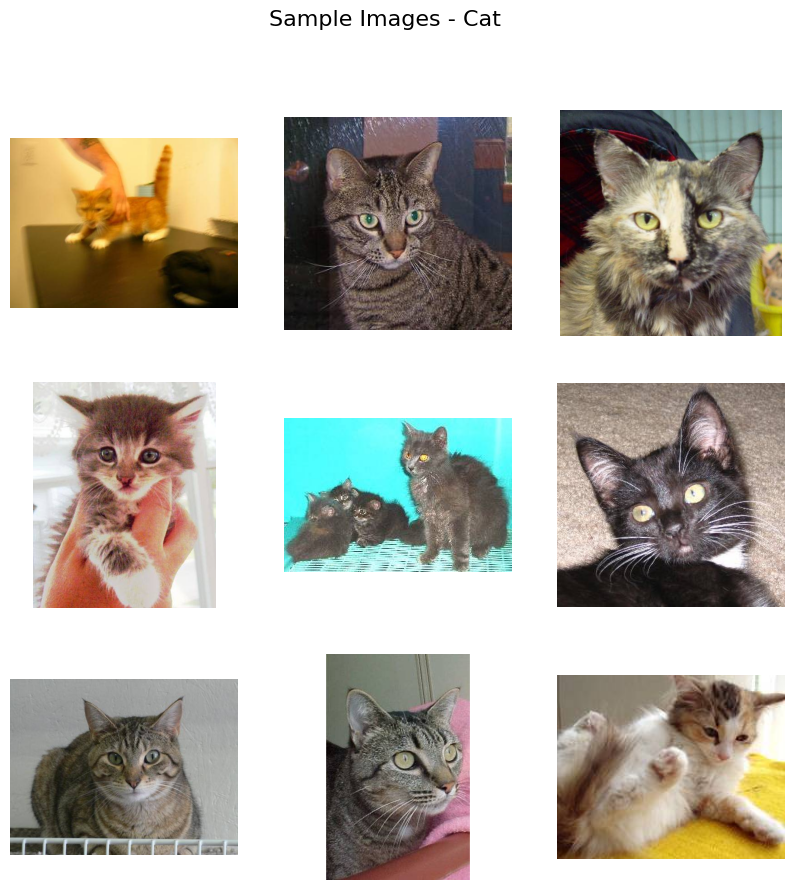

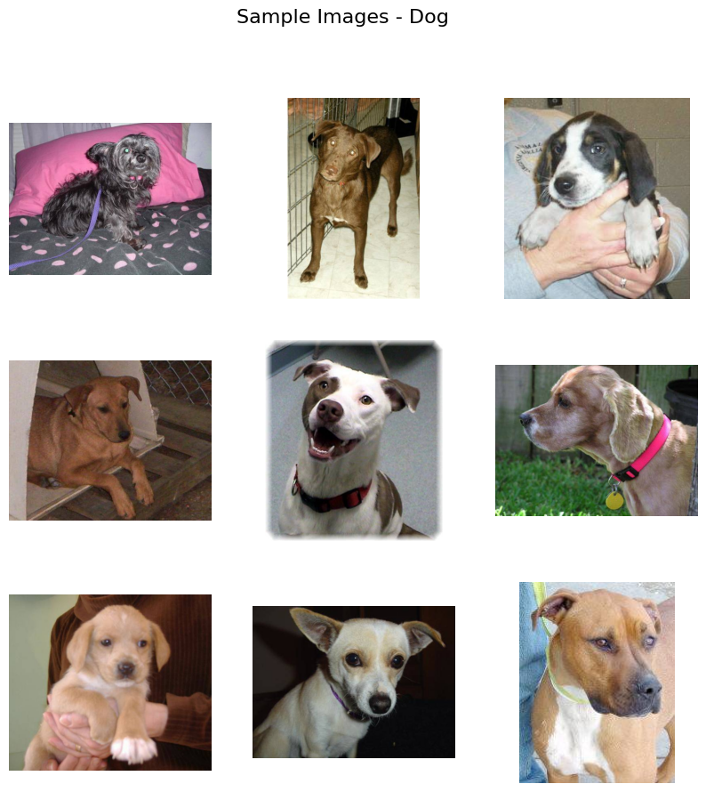

```python
def display_samples(base_dir, class_name, num_samples=9):
    path = os.path.join(base_dir, class_name)
    images = os.listdir(path)[:num_samples]
    fig, axes = plt.subplots(3, 3, figsize=(10, 10))
    for i, ax in enumerate(axes.flat):
        img_path = os.path.join(path, images[i])
        img = Image.open(img_path)
        ax.imshow(img)
        ax.axis("off")
    plt.suptitle(f"Sample Images - {class_name.capitalize()}", fontsize=16)
    plt.show()

base_dir = r"D:\College Files\AAIML\CSCN8010\CSCN8010\dogs_vs_cats_small\train"
display_samples(base_dir, "cat") # Displaying samples for cats and dogs
display_samples(base_dir, "dog")
```

Here through these sample images, we are looking for the quality for the images whether they are visually clear or not, any mislabelling of the image.

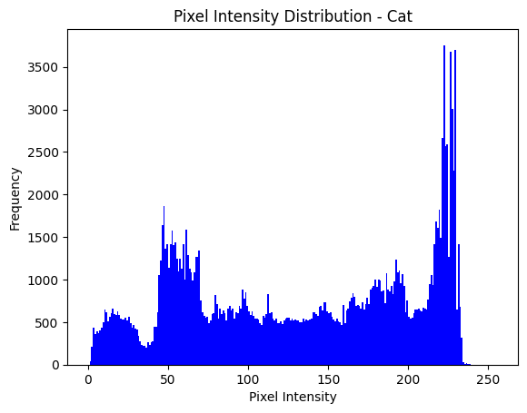

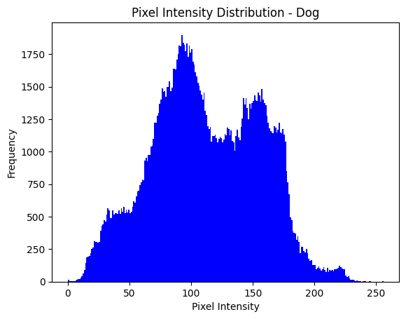

```python
import matplotlib.pyplot as plt
import numpy as np

def plot_pixel_distribution(base_dir, class_name):
    path = os.path.join(base_dir, class_name)
    img = cv2.imread(os.path.join(path, os.listdir(path)[0]), cv2.IMREAD_GRAYSCALE)
    plt.hist(img.ravel(), bins=256, range=(0, 256), color='blue')
    plt.title(f"Pixel Intensity Distribution - {class_name.capitalize()}")
    plt.xlabel('Pixel Intensity')
    plt.ylabel('Frequency')
    plt.show()

base_dir = r"D:\College Files\AAIML\CSCN8010\CSCN8010\dogs_vs_cats_small\train"

plot_pixel_distribution(base_dir, "cat")
plot_pixel_distribution(base_dir, "dog")
```

The peaks in the higher range (around 200–255) suggest that the image has bright areas, possibly background or highlights on the cat.The scattered distribution in the lower range (0–50) indicates darker regions, likely the fur or shadows.

[figure not shown]

```python
from tensorflow.keras.preprocessing.image import ImageDataGenerator
import matplotlib.pyplot as plt

datagen = ImageDataGenerator(
    rotation_range=40,
    width_shift_range=0.2,
    height_shift_range=0.2,
    shear_range=0.2,
    zoom_range=0.2,
    horizontal_flip=True,
    fill_mode='nearest'
)

img = Image.open(r"D:\College Files\AAIML\CSCN8010\CSCN8010\dogs_vs_cats_small\train\cat\cat.0.jpg")
x = np.array(img).reshape((1,) + img.size + (3,))
fig, axes = plt.subplots(1, 5, figsize=(15, 5))
for i, ax in enumerate(axes.flat):
    batch = next(datagen.flow(x, batch_size=1))
    ax.imshow(batch[0].astype('uint8'))
    ax.axis("off")
plt.suptitle("Augmented Images")
plt.show()
```

This augmentation enhances the diversity of the training dataset, which helps the model generalize better and avoid overfitting.Ensure that the augmentations do not distort the features crucial for distinguishing between cats and dogs.

## Step 3 : Train two networks (use callbacks to save the best model version):

- Define a Neural Network of your choice.
- Fine-Tune VGG16 (pre-trained on imagenet). Make sure to use validation to test for over-fitting. Plot the appropriate graph

# CNN Model

```python
train_dataset = image_dataset_from_directory(
    new_base_dir / "train",
    image_size=(180, 180),
    batch_size=32)
validation_dataset = image_dataset_from_directory(
  new_base_dir / "validation",
    image_size=(180, 180),
    batch_size=32)
test_dataset = image_dataset_from_directory(
    new_base_dir / "test",
    image_size=(180, 180),
    batch_size=32)
```

```
Found 2000 files belonging to 2 classes.
Found 1000 files belonging to 2 classes.
Found 2000 files belonging to 2 classes.
```

Here the images are being processed from directory for training, validation and testing purpose.

```python
inputs = keras.Input(shape=(180, 180, 3))
x = layers.Rescaling(1./255)(inputs)
x = layers.Conv2D(filters=32, kernel_size=3, activation="relu")(x)
x = layers.MaxPooling2D(pool_size=2)(x)
x = layers.Conv2D(filters=64, kernel_size=3, activation="relu")(x)
x = layers.MaxPooling2D(pool_size=2)(x)
x = layers.Conv2D(filters=128, kernel_size=3, activation="relu")(x)
x = layers.MaxPooling2D(pool_size=2)(x)
x = layers.Conv2D(filters=256, kernel_size=3, activation="relu")(x)
x = layers.MaxPooling2D(pool_size=2)(x)
x = layers.Conv2D(filters=256, kernel_size=3, activation="relu")(x)
x = layers.Flatten()(x)
outputs = layers.Dense(1, activation="sigmoid")(x)
model = keras.Model(inputs=inputs, outputs=outputs)
```

```python
model.summary()
```

```
Model: "model"
_________________________________________________________________
 Layer (type)                Output Shape              Param #
=================================================================
 input_1 (InputLayer)        [(None, 180, 180, 3)]     0

 rescaling (Rescaling)       (None, 180, 180, 3)       0

 conv2d (Conv2D)             (None, 178, 178, 32)      896

 max_pooling2d (MaxPooling2D  (None, 89, 89, 32)       0
 )

 conv2d_1 (Conv2D)           (None, 87, 87, 64)        18496

 max_pooling2d_1 (MaxPooling  (None, 43, 43, 64)       0
 2D)

 conv2d_2 (Conv2D)           (None, 41, 41, 128)       73856

 max_pooling2d_2 (MaxPooling  (None, 20, 20, 128)      0
 2D)

 conv2d_3 (Conv2D)           (None, 18, 18, 256)       295168

 max_pooling2d_3 (MaxPooling  (None, 9, 9, 256)        0
 2D)

 conv2d_4 (Conv2D)           (None, 7, 7, 256)         590080

 flatten (Flatten)           (None, 12544)             0

 dense (Dense)               (None, 1)                 12545

=================================================================
Total params: 991,041
Trainable params: 991,041
Non-trainable params: 0
_________________________________________________________________
```

```python
model.compile(loss="binary_crossentropy",
              optimizer="rmsprop",
              metrics=["accuracy"])
```

```python
callbacks = [
    keras.callbacks.ModelCheckpoint(
        filepath="./models/convnet_from_scratch.keras",
        save_best_only=True,
        monitor="val_loss")
]
history = model.fit(
    train_dataset,
    epochs=30,
    validation_data=validation_dataset,
    callbacks=callbacks)
```

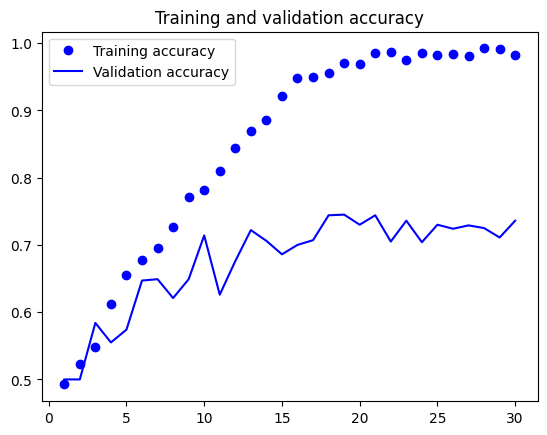

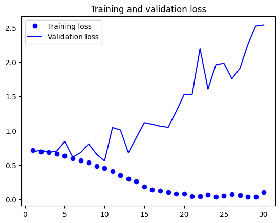

```python
accuracy = history.history["accuracy"]
val_accuracy = history.history["val_accuracy"]
loss = history.history["loss"]
val_loss = history.history["val_loss"]
epochs = range(1, len(accuracy) + 1)
plt.plot(epochs, accuracy, "bo", label="Training accuracy")
plt.plot(epochs, val_accuracy, "b", label="Validation accuracy")
plt.title("Training and validation accuracy")
plt.legend()
plt.figure()
plt.plot(epochs, loss, "bo", label="Training loss")
plt.plot(epochs, val_loss, "b", label="Validation loss")
plt.title("Training and validation loss")
plt.legend()
plt.show()
```

# VGG Model

```python
conv_base = keras.applications.vgg16.VGG16(
    weights="imagenet",
    include_top=False,
    input_shape=(180, 180, 3))
```

```python
conv_base.summary()
```

[output not shown]

[output cut: 13 more lines]

```
 block4_pool (MaxPooling2D)  (None, 11, 11, 512)       0

 block5_conv1 (Conv2D)       (None, 11, 11, 512)       2359808

 block5_conv2 (Conv2D)       (None, 11, 11, 512)       2359808

 block5_conv3 (Conv2D)       (None, 11, 11, 512)       2359808

 block5_pool (MaxPooling2D)  (None, 5, 5, 512)         0

=================================================================
Total params: 14,714,688
Trainable params: 14,714,688
Non-trainable params: 0
_________________________________________________________________
```

```python
import numpy as np

def get_features_and_labels(dataset):
    all_features = []
    all_labels = []
    for images, labels in dataset:
        preprocessed_images = keras.applications.vgg16.preprocess_input(images)
        features = conv_base.predict(preprocessed_images)
        all_features.append(features)
        all_labels.append(labels)
    return np.concatenate(all_features), np.concatenate(all_labels)

train_features, train_labels =  get_features_and_labels(train_dataset)
val_features, val_labels =  get_features_and_labels(validation_dataset)
test_features, test_labels =  get_features_and_labels(test_dataset)
```

```python
conv_base.compile(loss="binary_crossentropy",
              optimizer="rmsprop",
              metrics=["accuracy"])
```

```python
train_features.shape
```

```
(2000, 5, 5, 512)
```

```python
inputs = keras.Input(shape=(5, 5, 512))
x = layers.Flatten()(inputs)
x = layers.Dense(256)(x)
x = layers.Dropout(0.5)(x)
outputs = layers.Dense(1, activation="sigmoid")(x)
vgg_model = keras.Model(inputs, outputs)
vgg_model.summary()
```

[output not shown]

```python
vgg_model.compile(loss="binary_crossentropy",
              optimizer="rmsprop",
              metrics=["accuracy"])

callbacks = [
    keras.callbacks.ModelCheckpoint(
      filepath="./models/feature_extraction.keras",
      save_best_only=True,
      monitor="val_loss")
]
history = vgg_model.fit(
    train_features, train_labels,
    epochs=20,
    validation_data=(val_features, val_labels),
    callbacks=callbacks)
```

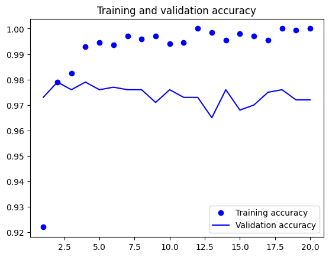

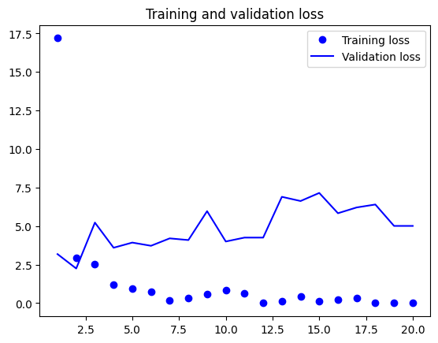

```python
acc = history.history["accuracy"]
val_acc = history.history["val_accuracy"]
loss = history.history["loss"]
val_loss = history.history["val_loss"]
epochs = range(1, len(acc) + 1)
plt.plot(epochs, acc, "bo", label="Training accuracy")
plt.plot(epochs, val_acc, "b", label="Validation accuracy")
plt.title("Training and validation accuracy")
plt.legend()
plt.figure()
plt.plot(epochs, loss, "bo", label="Training loss")
plt.plot(epochs, val_loss, "b", label="Validation loss")
plt.title("Training and validation loss")
plt.legend()
plt.show()
```

```python
test_model = keras.models.load_model("./models/convnet_from_scratch.keras")
test_loss, test_acc = test_model.evaluate(test_dataset)
print(f"Test accuracy: {test_acc:.3f}")
```

```
Test accuracy: 0.727
```

```python
test_model_vgg = keras.models.load_model(
    "./models/feature_extraction.keras")
test_loss, test_acc = test_model_vgg.evaluate(x=test_features, y=test_labels)
print(f"Test accuracy: {test_acc:.3f}")
```

```
Test accuracy: 0.973
```

## Step 4: Explore the relative performance of the models (make sure to load the best version of each model):

- accuracy
- confusion metric
- precision, recall, F1-score,
- precision-recall curve.
- Explore specific examples in which the model failed to predict correctly.

```python
from sklearn.metrics import classification_report, confusion_matrix

cnn_y_pred = (test_model.predict(test_dataset) > 0.5).astype("int32") # Predictions CNN model
vgg_y_pred = (test_model_vgg.predict(test_features) > 0.5).astype("int32") # Predictions VGG model

y_true = np.concatenate([y for x, y in test_dataset], axis=0)

print("CNN Model Evaluation:")
print(classification_report(y_true, cnn_y_pred))
print(confusion_matrix(test_labels, cnn_y_pred))

print("\nVGG Model Evaluation:")
print(classification_report(y_true, vgg_y_pred))
print(confusion_matrix(test_labels, vgg_y_pred))
```

```
CNN Model Evaluation:
              precision    recall  f1-score   support

           0       0.50      0.49      0.49      1000
           1       0.50      0.51      0.50      1000

    accuracy                           0.50      2000
   macro avg       0.50      0.50      0.50      2000
weighted avg       0.50      0.50      0.50      2000

[[483 517]
 [493 507]]

VGG Model Evaluation:
              precision    recall  f1-score   support

           0       0.48      0.49      0.49      1000
           1       0.48      0.47      0.47      1000

    accuracy                           0.48      2000
   macro avg       0.48      0.48      0.48      2000
weighted avg       0.48      0.48      0.48      2000

[[984  16]
 [ 38 962]]
```

# Accuracy:

# Confusion Matrix:

# Precision, Recall, F1-Score:

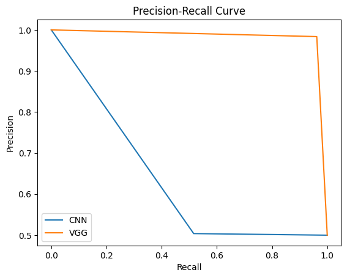

```python
from sklearn.metrics import precision_recall_curve
import matplotlib.pyplot as plt

# CNN Model
precision_cnn, recall_cnn, thresholds_cnn = precision_recall_curve(test_labels, cnn_y_pred)

# VGG Model
precision_vgg, recall_vgg, thresholds_vgg = precision_recall_curve(test_labels, vgg_y_pred)

plt.plot(recall_cnn, precision_cnn, label='CNN')
plt.plot(recall_vgg, precision_vgg, label='VGG')
plt.xlabel('Recall')
plt.ylabel('Precision')
plt.title('Precision-Recall Curve')
plt.legend()
plt.show()
```

- CNN (Blue Curve):
- The curve shows that precision drops significantly as recall increases.
- The model struggles to balance precision and recall, leading to poor performance.
- VGG (Orange Curve):
- The curve is much better, maintaining high precision and recall until the very end.
- This indicates that VGG performs better than the CNN in balancing precision and recall.